# In Class Exercises

## Thinking about probabilities

Why learn probability?

- You could learn all the statistical analyses/tests without really understanding probability.

## Should the Packers have gone for 2?

### 2015 NFL playoffs

Packers score on a hail mary touchdown to trail by 1 point at the end of the game.

[figure not shown]

## Should the Packers have gone for 2?

Two-point conversion + win:

- League-wide success rate (since 2003): 431 of 913

Extra point + overtime:

- Extra point success rate (2015 only; after the extra point attempt was moved back): 1,131 of 1,199
- Expected winning percentage in overtime (since 2001): Away team has won 110 of 242 games

## Should the Packers have gone for 2?

```r
# 2-pt conversion
431/913
```

```
## [1] 0.4720701
```

```r
# Extra point + overtime
(1131 / 1199) * (110 / 242)
```

```
## [1] 0.4287664
```

```r
# Odds
(431/913) / ((1131 / 1199) * (110 / 242))
```

```
## [1] 1.100996
```

## Should the Packers have gone for 2?

[figure not shown]

## Binomial probabilities

About 10% of people are left handed.

- What is the probability of exactly 0 left handed people in a *random sample* of 25?
- What is the probability of exactly 1?
- What is the probability of 1 *or more*?

## Binomial probabilities

Probability density functions in R: `dbinom()`, `dnorm()`, `dpois()`, etc.

`dbinom(x, size, prob)`

- `x` = Number of “successes”
- `size` = Sample size
- `prob` = Probability of success for each trial

## Binomial probabilities

What is the probability of 0 left handed people in a *sample* of 25?

```r
dbinom(0, 25, prob = 0.1)
```

## Binomial probabilities

What is the probability of 0 left handed people in a *sample* of 25?

```r
dbinom(0, 25, prob = 0.1)
```

```
## [1] 0.0717898
```

## Binomial probabilities

What is the probability of exactly 1?

## Binomial probabilities

What is the probability of exactly 1?

```r
dbinom(1, 25, prob = 0.1)
```

```
## [1] 0.1994161
```

## Binomial probabilities

What is the probability of 1 *or more*?

## Binomial probabilities

What is the probability of 1 *or more*?

```r
sum(dbinom(1:25, 25, prob = 0.1))
```

```
## [1] 0.9282102
```

*“or more”* is critical here for hypothesis testing:

- Probability of the observed data or any *more extreme*

## Binomial probabilities for Pr[left] = 0.1

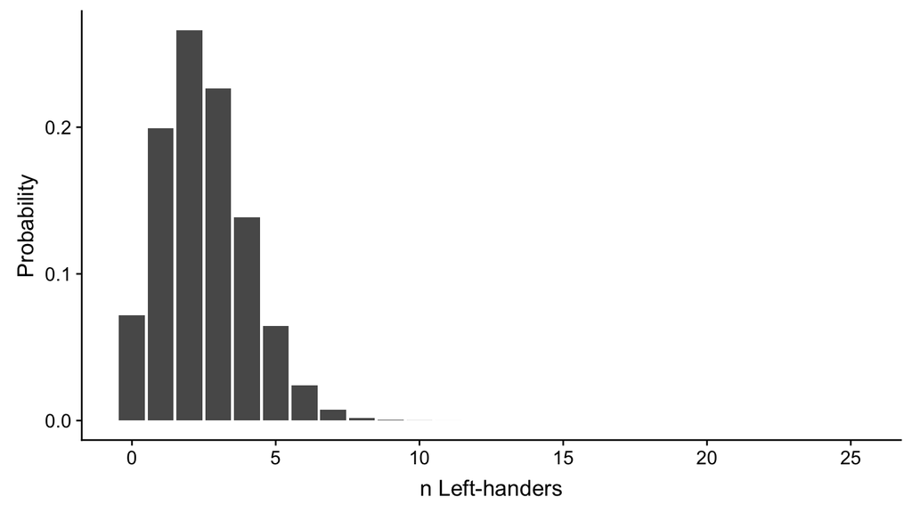

\(n > 8\) have very low probabilities.

## Binomial probabilities for Pr[left] = 0.1

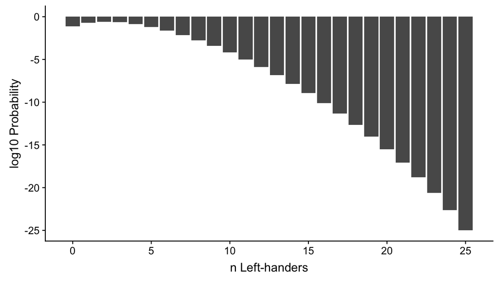

## Reached Via a Mind-Reading Device…

[… Deeply Paralyzed Patients Say They Want to Live](https://www.technologyreview.com/s/603512/reached-via-a-mind-reading-device-deeply-paralyzed-patients-say-they-want-to-live/?set=603545)

> In response to the statement “I love to live” three of the four replied yes.

> To verify the four could communicate, Birbaumer’s team asked patients, over the course of about 10 days of testing, to respond yes or no to statements such as “You were born in Berlin” or “Paris is the capital of Germany” by modulating their thoughts and altering the blood-flow pattern. The answers relayed through the system were consistent about 70 percent of the time, substantially better than chance.

## Powerball

1. 69 balls in one pool: Choose 5
2. 26 in the other pool: Choose 1

Number of winning combinations in pool 1 is the **binomial coefficient**

- the number of unique ordered sequences of successes that yield exactly \(k\) successes from \(n\) trials (“n choose k”).
- the “successes” can happen in any order
- `choose(n, k)`

\[\left({n\atop k}\right)=\frac{n!}{k!\left(n - k\right)!}\]

## Powerball

1. 69 balls in one pool: Choose 5
2. 26 in the other pool: Choose 1

```r
choose(69, 5)
```

```
## [1] 11238513
```

```r
choose(26, 1)
```

```
## [1] 26
```

## Powerball

5 successes from 69 chances \(\times\) 1 success from 26 chances.

```r
choose(69, 5) * choose(26, 1)
```

```
## [1] 292201338
```

What if the order had to be correct as well?

## Conditional probability thought experiment

A coin is tossed 100 times. Gamblers can bet on the total number of heads that will be thrown. They can do so at any time before or during the game.

- Imagine that you’re betting before the game starts. What is your best bet?

## Conditional probability thought experiment

Now imagine that you’re betting after the coin was already tossed 10 times and came up heads all 10 times.

- What is the best bet now?

## Breast cancer screening

Approximately correct numbers:

1. 1 in 100 women in the age range 40-50 have breast cancer
2. 80% with cancer have a positive mammogram (true positives)
3. 10% without cancer have a positive mammogram (false positives)

What is the probability of a randomly sampled woman having breast cancer, given a positive test?

## Breast cancer screening

\[Pr[C|T] = \frac{Pr[T|C] \times Pr[C]}{Pr[T]}\]

- \(Pr[T|C] = 0.8\)
- \(Pr[C] = 1/100 = 0.01\)
- \(Pr[T]\) = ???

## Breast cancer screening

\[Pr[C|T] = \frac{Pr[T|C] \times Pr[C]}{Pr[T]}\]

- \(Pr[T|C] = 0.8\)
- \(Pr[C] = 1/100 = 0.01\)
- \(Pr[T] = (0.8 \times 0.01) + (0.1 \times 0.99)\)

## Breast cancer screening

\[Pr[C|T] = \frac{Pr[T|C] \times Pr[C]}{Pr[T]}\]

- \(Pr[T|C] = 0.8\)
- \(Pr[C] = 0.01\)
- \(Pr[T] = (0.8 \times 0.01) + (0.1 \times 0.99)\)

```r
(0.8 * 0.01) / ((0.8 * 0.01) + (0.1 * 0.99))
```

```
## [1] 0.07476636
```